# Final Project: Ten-Minute Analytics Challenge

```python
# define the gridsearch for the decision tree regression:

dtr_grid_search = GridSearchCV(DTsalesreg, dtr_param_grid, cv=5, scoring='neg_mean_squared_error')
```

```python
# Fit the model on training data
# Since we are using the training portion of the data, we are now "training" our model.
dtr_grid_search.fit(X_train, Y_train)
```

[output not shown]

[output cut: 585 more lines]

[output not shown]

[output not shown]

```python
df_elsalvador_bl_co_merged3.fillna(0,inplace=True)
```

Each row in the dataFrame corresponds to a company and it is tricky to fill the missing data. We cannot use median or mean values to fill the missing data for any column as this would apply to all rows wherever null value is present such as *dfSoy.fillna({'precip' : dfSoy['precip'].mean(), 'temp':dfSoy['temp'].median()}, inplace=True)*  
because the survey is not for a single entity but multiple entities/companies and we cannot generalize the sales figure or the obstacles faced, percentage sales direct, indirect exports etc. if the value is Dont know because all these attributes are company-specific, therefore cant be generalized per se.

### These are the input/output variables

```python
# First, define the X (predictor/independent) and the Y (predicted/dependent) variables:
# SciKit doesn't work with Pandas dataframes, so we just need the matrix of values.

X = df_elsalvador_bl_co_merged3[['transport_deg_obs', 'customs_trade_reg_deg_obs',
       'insuff_acc_fin_deg_obs', 'insuff_exp_gua_deg_obs',
       'high_trnspt_costs_deg_obs', 'LACd10e_deg_obs', 'estbl_status',
       'is_estbl_closed_temp', 'no_weeks_estbl_closed', 'pct_sales_incr',
       'pct_sales_national_y',
       'pct_sales_indirect_exports_y', 'pct_sales_direct_exports_y',
       'pct_dir_indir_exports_status', 'is_estbl_adjusted',
       'estbl_total_work_hrs_status', 'estbl_demand_status',
       'estbl_supply_inputs_status', 'is_biz_actvty_online',
       'is_delivery_goods_svc', 'is_remote_work_agmt',
       'is_digital_platforms_biz_admin',
       'is_digital_platforms_supply_chn_mgmt', 'is_digital_platforms_mktg',
       'is_digital_platforms_sale', 'is_digital_platforms_paymt_meth',
       'is_digital_platforms_svc_dvy', 'pct_workforce_remote',
       'pct_online_sales', 'pct_share_digi_pltms_web_sales',
       'is_estbl_invested_digi_sol']].values
Y = df_elsalvador_bl_co_merged3.pct_sales_decr
```

```python
# Second, split the data into training and test portions:
# I am using 25% of data for testing and 75% for training.

X_train, X_test, Y_train, Y_test = train_test_split(X, Y, test_size=0.25, random_state=7)
print(X_train.shape, Y_train.shape)
print(X_test.shape, Y_test.shape)
```

```
(51, 31) (51,)
(17, 31) (17,)
```

```python
DTsalesreg=DecisionTreeRegressor(random_state=23)
```

```python
# set the gridsearch parameters for the decision tree regression
dtr_param_grid={'max_depth':[3,5,7,10], 'max_leaf_nodes':np.arange(2,10)}
```

```python
# define the gridsearch for the decision tree regression:

dtr_grid_search = GridSearchCV(DTsalesreg, dtr_param_grid, cv=5, scoring='neg_mean_squared_error')
```

```python
# Fit the model on training data
# Since we are using the training portion of the data, we are now "training" our model.
dtr_grid_search.fit(X_train, Y_train)
```

```
GridSearchCV(cv=5, error_score=nan,
             estimator=DecisionTreeRegressor(ccp_alpha=0.0, criterion='mse',
                                             max_depth=None, max_features=None,
                                             max_leaf_nodes=None,
                                             min_impurity_decrease=0.0,
                                             min_impurity_split=None,
                                             min_samples_leaf=1,
                                             min_samples_split=2,
                                             min_weight_fraction_leaf=0.0,
                                             presort='deprecated',
                                             random_state=23, splitter='best'),
             iid='deprecated', n_jobs=None,
             param_grid={'max_depth': [3, 5, 7, 10],
                         'max_leaf_nodes': array([2, 3, 4, 5, 6, 7, 8, 9])},
             pre_dispatch='2*n_jobs', refit=True, return_train_score=False,
             scoring='neg_mean_squared_error', verbose=0)
```

```python
dtr_grid_search.cv_results_['mean_test_score']
```

```
array([-631.60450129, -553.85564521, -681.90427366, -720.6935329 ,
       -720.6935329 , -720.6935329 , -720.6935329 , -720.6935329 ,
       -631.60450129, -553.85564521, -681.90427366, -727.62560093,
       -770.18600983, -811.13739872, -824.94179534, -848.93728423,
       -631.60450129, -553.85564521, -681.90427366, -727.62560093,
       -770.18600983, -800.1416677 , -805.61538036, -867.66546783,
       -631.60450129, -553.85564521, -681.90427366, -727.62560093,
       -770.18600983, -800.1416677 , -805.61538036, -867.66546783])
```

```python
dtr_grid_search.best_params_
```

```
{'max_depth': 3, 'max_leaf_nodes': 3}
```

```python
dtr_grid_search.best_estimator_
```

```
DecisionTreeRegressor(ccp_alpha=0.0, criterion='mse', max_depth=3,
                      max_features=None, max_leaf_nodes=3,
                      min_impurity_decrease=0.0, min_impurity_split=None,
                      min_samples_leaf=1, min_samples_split=2,
                      min_weight_fraction_leaf=0.0, presort='deprecated',
                      random_state=23, splitter='best')
```

We can visualize the Decision Tree from the best*estimator* as following:

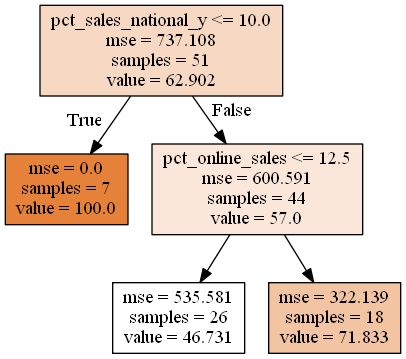

```python
DTRgraph = print_tree(dtr_grid_search.best_estimator_, features=['transport_deg_obs', 'customs_trade_reg_deg_obs',
       'insuff_acc_fin_deg_obs', 'insuff_exp_gua_deg_obs',
       'high_trnspt_costs_deg_obs', 'LACd10e_deg_obs', 'estbl_status',
       'is_estbl_closed_temp', 'no_weeks_estbl_closed', 'pct_sales_incr',
       'pct_sales_national_y',
       'pct_sales_indirect_exports_y', 'pct_sales_direct_exports_y',
       'pct_dir_indir_exports_status', 'is_estbl_adjusted',
       'estbl_total_work_hrs_status', 'estbl_demand_status',
       'estbl_supply_inputs_status', 'is_biz_actvty_online',
       'is_delivery_goods_svc', 'is_remote_work_agmt',
       'is_digital_platforms_biz_admin',
       'is_digital_platforms_supply_chn_mgmt', 'is_digital_platforms_mktg',
       'is_digital_platforms_sale', 'is_digital_platforms_paymt_meth',
       'is_digital_platforms_svc_dvy', 'pct_workforce_remote',
       'pct_online_sales', 'pct_share_digi_pltms_web_sales',
       'is_estbl_invested_digi_sol'])
Image(DTRgraph.create_png())
```

```python
# Get the predicted values and evaluate the model:

DT_predictions_tr=dtr_grid_search.best_estimator_.predict(X_test) # predictions for test set
```

```python
# How good is this prediction?

np.sqrt(np.square(DT_predictions_tr-Y_test).mean()) #RMSE calculation
```

```
24.84133761245539
```

Interpretation: Our model is deviant from the actual values by about 24.8%, on average when using the test data. Moreover, It depends on how good the accuracy has to be depending on the context.

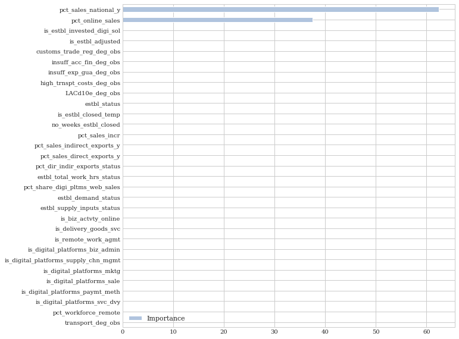

```python
#Getting the importance of features from the best model:
%matplotlib inline
Importance = pd.DataFrame({'Importance':dtr_grid_search.best_estimator_.feature_importances_*100}, \
                          index=['transport_deg_obs', 'customs_trade_reg_deg_obs',
       'insuff_acc_fin_deg_obs', 'insuff_exp_gua_deg_obs',
       'high_trnspt_costs_deg_obs', 'LACd10e_deg_obs', 'estbl_status',
       'is_estbl_closed_temp', 'no_weeks_estbl_closed', 'pct_sales_incr',
       'pct_sales_national_y',
       'pct_sales_indirect_exports_y', 'pct_sales_direct_exports_y',
       'pct_dir_indir_exports_status', 'is_estbl_adjusted',
       'estbl_total_work_hrs_status', 'estbl_demand_status',
       'estbl_supply_inputs_status', 'is_biz_actvty_online',
       'is_delivery_goods_svc', 'is_remote_work_agmt',
       'is_digital_platforms_biz_admin',
       'is_digital_platforms_supply_chn_mgmt', 'is_digital_platforms_mktg',
       'is_digital_platforms_sale', 'is_digital_platforms_paymt_meth',
       'is_digital_platforms_svc_dvy', 'pct_workforce_remote',
       'pct_online_sales', 'pct_share_digi_pltms_web_sales',
       'is_estbl_invested_digi_sol'])
Importance.sort_values('Importance', axis=0, ascending=True).plot(kind='barh', color='lightsteelblue', )
plt.gcf().set_size_inches(10, 10)
```

#### Model 4 - Honduras - We shall go with the Random Forest Classifier with GridSearchCV Dependent Variable to predict - is_sales_increased - Categorical Variable - corresponds to the question no. 'COVb2a' of the survey

```python
df_honduras_bl_co_merged.head()
```

|  | idstd | id_x | d1a1x | d8 | d14 | transport_deg_obs | customs_trade_reg_deg_obs | losses_theft | losses_breakage_spoilage | total_sales_fy13 | ... | is_digital_platforms_biz_admin | is_digital_platforms_supply_chn_mgmt | is_digital_platforms_mktg | is_digital_platforms_sale | is_digital_platforms_paymt_meth | is_digital_platforms_svc_dvy | pct_workforce_remote | pct_online_sales | pct_share_digi_pltms_web_sales | is_estbl_invested_digi_sol |
| --- | --- | --- | --- | --- | --- | --- | --- | --- | --- | --- | --- | --- | --- | --- | --- | --- | --- | --- | --- | --- | --- |
| 0 | 621118 | 10 | Synthetic Leather For Tennis Shoes | NaN | 15 | 3.0 | 2.0 | 0.0 | 0.0 | 16000000.0 | ... | NaN | NaN | NaN | NaN | NaN | NaN | NaN | NaN | NaN | NaN |
| 1 | 621119 | 11 | Electric Appliances (Tv´S And Smart Tv) | NaN | NaN | 0.0 | 0.0 | 0.0 | 0.0 | 2875045.0 | ... | NaN | NaN | NaN | NaN | NaN | NaN | NaN | NaN | NaN | NaN |
| 2 | 621120 | 25 | Mobile Devices Gadgets (Nite Brand) | NaN | 3 | 0.0 | 0.0 | 0.0 | 0.0 | NaN | ... | NaN | NaN | NaN | NaN | NaN | NaN | 0.0 | 0.0 | NaN | NaN |
| 3 | 621121 | 45 | Imported Electronics | NaN | 10 | 3.0 | 4.0 | 5.0 | 2.0 | 1000000.0 | ... | 1.0 | 0.0 | 1.0 | 1.0 | 1.0 | 0.0 | 0.0 | 0.0 | NaN | NaN |
| 4 | 621124 | 126 | Computers | NaN | 12 | 3.0 | 3.0 | 0.0 | NaN | 10500000.0 | ... | NaN | NaN | NaN | NaN | NaN | NaN | NaN | NaN | NaN | NaN |

5 rows × 58 columns

```python
df_honduras_bl_co_merged.columns
```

```
Index(['idstd', 'id_x', 'd1a1x', 'd8', 'd14', 'transport_deg_obs',
       'customs_trade_reg_deg_obs', 'losses_theft', 'losses_breakage_spoilage',
       'total_sales_fy13', 'pct_sales_national_x',
       'pct_sales_indirect_exports_x', 'pct_sales_direct_exports_x',
       'total_sales', 'insuff_acc_fin_deg_obs', 'insuff_exp_gua_deg_obs',
       'high_trnspt_costs_deg_obs', 'LACd10e_deg_obs', 'is_export_fac_svc',
       'expect_vol_direct_exports', 'expect_vol_direct_exports_val',
       'is_prov_affect_cap_export', 'prov_affect_cap_export',
       'pct_sales_main_prod', 'pct_supplies_resell_domestic',
       'pct_supplies_resell_foreign', 'is_supplies_resell_imported_directly',
       'id_y', 'BPS5h', 'BPS5h1x', 'eligibilitycode', 'estbl_status',
       'is_estbl_closed_temp', 'no_weeks_estbl_closed', 'is_sales_changed',
       'pct_sales_incr', 'pct_sales_decr', 'pct_sales_national_y',
       'pct_sales_indirect_exports_y', 'pct_sales_direct_exports_y',
       'pct_dir_indir_exports_status', 'is_estbl_adjusted',
       'estbl_total_work_hrs_status', 'estbl_demand_status',
       'estbl_supply_inputs_status', 'is_biz_actvty_online',
       'is_delivery_goods_svc', 'is_remote_work_agmt',
       'is_digital_platforms_biz_admin',
       'is_digital_platforms_supply_chn_mgmt', 'is_digital_platforms_mktg',
       'is_digital_platforms_sale', 'is_digital_platforms_paymt_meth',
       'is_digital_platforms_svc_dvy', 'pct_workforce_remote',
       'pct_online_sales', 'pct_share_digi_pltms_web_sales',
       'is_estbl_invested_digi_sol'],
      dtype='object')
```

```python
df_honduras_bl_co_merged.is_sales_changed.unique()
```

```
array([nan, -1.,  1.,  0.])
```

```python
df_honduras_bl_co_merged.is_sales_changed.isna().sum()
```

```
115
```

Filling the missing values:-

```python
df_honduras_bl_co_merged.fillna({'is_sales_changed' : 0}, inplace=True)
```

```python
df_honduras_bl_co_merged.is_sales_changed.isna().sum()
```

```
0
```

```python
df_elsalvador_bl_co_merged.is_sales_changed.unique()
```

```
array([-1.,  0.,  1.])
```

```python
df_honduras_bl_co_merged['is_sales_increased'] = df_honduras_bl_co_merged['is_sales_changed'].apply(get_numerical_val_5)
df_honduras_bl_co_merged[['is_sales_changed','is_sales_increased']][df_honduras_bl_co_merged.is_sales_changed < 0]
```

|  | is_sales_changed | is_sales_increased |
| --- | --- | --- |
| 2 | -1.0 | 0 |
| 5 | -1.0 | 0 |
| 74 | -1.0 | 0 |
| 75 | -1.0 | 0 |

```python
df_honduras_bl_co_merged[['is_sales_changed','is_sales_increased']][df_honduras_bl_co_merged.is_sales_changed == 0]
```

|  | is_sales_changed | is_sales_increased |
| --- | --- | --- |
| 0 | 0.0 | 0 |
| 1 | 0.0 | 0 |
| 3 | 0.0 | 0 |
| 4 | 0.0 | 0 |
| 6 | 0.0 | 0 |
| ... | ... | ... |
| 116 | 0.0 | 0 |
| 117 | 0.0 | 0 |
| 118 | 0.0 | 0 |
| 119 | 0.0 | 0 |
| 120 | 0.0 | 0 |

116 rows × 2 columns

```python
df_honduras_bl_co_merged[['is_sales_changed','is_sales_increased']][df_honduras_bl_co_merged.is_sales_changed == 1]
```

|  | is_sales_changed | is_sales_increased |
| --- | --- | --- |
| 45 | 1.0 | 1 |

```python
df_honduras_bl_co_merged2 = df_honduras_bl_co_merged.drop(columns=['idstd', 'id_x', 'd1a1x', 'd8', 'd14',
       'losses_theft', 'losses_breakage_spoilage',
       'total_sales','total_sales_fy13','pct_sales_national_x',
       'pct_sales_indirect_exports_x', 'pct_sales_direct_exports_x',
       'is_sales_changed','is_export_fac_svc',
       'expect_vol_direct_exports', 'expect_vol_direct_exports_val',
       'is_prov_affect_cap_export', 'prov_affect_cap_export',
       'pct_sales_main_prod', 'pct_supplies_resell_domestic',
       'pct_supplies_resell_foreign', 'is_supplies_resell_imported_directly',
       'id_y', 'BPS5h', 'BPS5h1x', 'eligibilitycode'
       ])
df_honduras_bl_co_merged2
```

|  | transport_deg_obs | customs_trade_reg_deg_obs | insuff_acc_fin_deg_obs | insuff_exp_gua_deg_obs | high_trnspt_costs_deg_obs | LACd10e_deg_obs | estbl_status | is_estbl_closed_temp | no_weeks_estbl_closed | pct_sales_incr | ... | is_digital_platforms_supply_chn_mgmt | is_digital_platforms_mktg | is_digital_platforms_sale | is_digital_platforms_paymt_meth | is_digital_platforms_svc_dvy | pct_workforce_remote | pct_online_sales | pct_share_digi_pltms_web_sales | is_estbl_invested_digi_sol | is_sales_increased |
| --- | --- | --- | --- | --- | --- | --- | --- | --- | --- | --- | --- | --- | --- | --- | --- | --- | --- | --- | --- | --- | --- |
| 0 | 3.0 | 2.0 | 4.0 | 1.0 | 2.0 | 4.0 | NaN | NaN | NaN | NaN | ... | NaN | NaN | NaN | NaN | NaN | NaN | NaN | NaN | NaN | 0 |
| 1 | 0.0 | 0.0 | 0.0 | 1.0 | 3.0 | 2.0 | NaN | NaN | NaN | NaN | ... | NaN | NaN | NaN | NaN | NaN | NaN | NaN | NaN | NaN | 0 |
| 2 | 0.0 | 0.0 | 0.0 | NaN | 0.0 | NaN | 0.0 | NaN | 10.0 | NaN | ... | NaN | NaN | NaN | NaN | NaN | 0.0 | 0.0 | NaN | NaN | 0 |
| 3 | 3.0 | 4.0 | NaN | NaN | NaN | NaN | 1.0 | 1.0 | 8.0 | NaN | ... | 0.0 | 1.0 | 1.0 | 1.0 | 0.0 | 0.0 | 0.0 | NaN | NaN | 0 |
| 4 | 3.0 | 3.0 | 3.0 | 3.0 | 3.0 | 3.0 | NaN | NaN | NaN | NaN | ... | NaN | NaN | NaN | NaN | NaN | NaN | NaN | NaN | NaN | 0 |
| ... | ... | ... | ... | ... | ... | ... | ... | ... | ... | ... | ... | ... | ... | ... | ... | ... | ... | ... | ... | ... | ... |
| 116 | 1.0 | 3.0 | 0.0 | NaN | NaN | 1.0 | 1.0 | 1.0 | 8.0 | NaN | ... | 0.0 | 1.0 | 1.0 | 1.0 | 1.0 | 0.0 | NaN | NaN | 1.0 | 0 |
| 117 | 0.0 | 4.0 | 2.0 | 0.0 | 0.0 | 0.0 | NaN | NaN | NaN | NaN | ... | NaN | NaN | NaN | NaN | NaN | NaN | NaN | NaN | NaN | 0 |
| 118 | 4.0 | 4.0 | 1.0 | 2.0 | 2.0 | 4.0 | NaN | NaN | NaN | NaN | ... | NaN | NaN | NaN | NaN | NaN | NaN | NaN | NaN | NaN | 0 |
| 119 | 3.0 | 1.0 | 1.0 | 1.0 | 0.0 | 2.0 | NaN | NaN | NaN | NaN | ... | NaN | NaN | NaN | NaN | NaN | NaN | NaN | NaN | NaN | 0 |
| 120 | 0.0 | NaN | 1.0 | NaN | NaN | 0.0 | 1.0 | 1.0 | 4.0 | 20.0 | ... | NaN | NaN | NaN | NaN | NaN | 0.0 | 0.0 | NaN | NaN | 0 |

121 rows × 33 columns

```python
yvar= df_honduras_bl_co_merged2.is_sales_increased.astype('float64')
Xvar = df_honduras_bl_co_merged2.drop(['is_sales_increased'], axis=1).astype('float64')
```

```python
# Split the data into training and test portions:

X2_train, X2_test, Y2_train, Y2_test = train_test_split(Xvar, yvar, test_size=0.25, random_state=7)
print(X2_train.shape, Y2_train.shape)
print(X2_test.shape, Y2_test.shape)
```

```
(90, 32) (90,)
(31, 32) (31,)
```

```python
# Select the model approach for fitting: RandomForest Classifier

DT_sales_rfc = RandomForestClassifier(random_state=23)
```

```python
# set the gridsearch parameters for the RandomForest Classifier
dtfc_param_grid={'n_estimators': [10, 15, 20], 'max_depth':[5, 10, 15], \
                 'max_leaf_nodes':np.arange(2,10), 'min_samples_split':[5, 10, 15]}
```

```python
# define the gridsearch for decision tree classification:
dtrfc_grid_search = GridSearchCV(DT_sales_rfc, dtfc_param_grid, cv=5, scoring='accuracy')
```

```python
# Fit the model on training data
# Since we are using the training portion of the data, we are now "training" our model.
dtrfc_grid_search.fit(X2_train, Y2_train)
```

[output not shown]

[output cut: 4265 more lines]

[output not shown]

[output not shown]

```python
df_honduras_bl_co_merged2.info()
```

```
<class 'pandas.core.frame.DataFrame'>
Int64Index: 121 entries, 0 to 120
Data columns (total 33 columns):
 #   Column                                Non-Null Count  Dtype
---  ------                                --------------  -----
 0   transport_deg_obs                     120 non-null    float64
 1   customs_trade_reg_deg_obs             114 non-null    float64
 2   insuff_acc_fin_deg_obs                103 non-null    float64
 3   insuff_exp_gua_deg_obs                87 non-null     float64
 4   high_trnspt_costs_deg_obs             90 non-null     float64
 5   LACd10e_deg_obs                       96 non-null     float64
 6   estbl_status                          46 non-null     float64
 7   is_estbl_closed_temp                  29 non-null     float64
 8   no_weeks_estbl_closed                 43 non-null     float64
 9   pct_sales_incr                        5 non-null      float64
```

[output cut: 25 more lines]

Initially assigned 0 to new variables when value is Dont know or Does not apply in original variable. Later changed it by assigning NaN, which increased the number of NaN values to the existing null values in csv  
Also, each row in the dataFrame corresponds to a company and it is tricky to fill the missing data. We cannot use median or mean values to fill the missing data for any column as this would apply to all rows wherever null value is present such as *dfSoy.fillna({'precip' : dfSoy['precip'].mean(), 'temp':dfSoy['temp'].median()}, inplace=True)*  
because the survey is not for a single entity but multiple entities/companies and we cannot generalize the sales figure or the obstacles faced, percentage sales direct, indirect exports etc. if the value is Dont know because all these attributes are company-specific, therefore cant be generalized per se.

```python
df_honduras_bl_co_merged2.fillna(0,inplace=True)
```

Let us re-build the model:-

### These are the input/output variables

```python
yvar= df_honduras_bl_co_merged2.is_sales_increased.astype('float64')
Xvar = df_honduras_bl_co_merged2.drop(['is_sales_increased'], axis=1).astype('float64')
```

```python
# Split the data into training and test portions:

X2_train, X2_test, Y2_train, Y2_test = train_test_split(Xvar, yvar, test_size=0.25, random_state=7)
print(X2_train.shape, Y2_train.shape)
print(X2_test.shape, Y2_test.shape)
```

```
(90, 32) (90,)
(31, 32) (31,)
```

#### We shall go with the Random Forest Classifier

```python
# Select the model approach for fitting: RandomForest Classifier

DT_sales_rfc = RandomForestClassifier(random_state=23)
```

```python
# set the gridsearch parameters for the RandomForest Classifier
dtfc_param_grid={'n_estimators': [10, 15, 20], 'max_depth':[5, 10, 15], \
                 'max_leaf_nodes':np.arange(2,10), 'min_samples_split':[5, 10, 15]}
```

```python
# define the gridsearch for decision tree classification:
dtrfc_grid_search = GridSearchCV(DT_sales_rfc, dtfc_param_grid, cv=5, scoring='accuracy')
```

```python
# Fit the model on training data
# Since we are using the training portion of the data, we are now "training" our model.
dtrfc_grid_search.fit(X2_train, Y2_train)
```

```
GridSearchCV(cv=5, error_score=nan,
             estimator=RandomForestClassifier(bootstrap=True, ccp_alpha=0.0,
                                              class_weight=None,
                                              criterion='gini', max_depth=None,
                                              max_features='auto',
                                              max_leaf_nodes=None,
                                              max_samples=None,
                                              min_impurity_decrease=0.0,
                                              min_impurity_split=None,
                                              min_samples_leaf=1,
                                              min_samples_split=2,
                                              min_weight_fraction_leaf=0.0,
                                              n_estimators=100, n_jobs=None,
                                              oob_score=False, random_state=23,
                                              verbose=0, warm_start=False),
             iid='deprecated', n_jobs=None,
             param_grid={'max_depth': [5, 10, 15],
                         'max_leaf_nodes': array([2, 3, 4, 5, 6, 7, 8, 9]),
                         'min_samples_split': [5, 10, 15],
                         'n_estimators': [10, 15, 20]},
             pre_dispatch='2*n_jobs', refit=True, return_train_score=False,
             scoring='accuracy', verbose=0)
```

```python
dtrfc_grid_search.cv_results_['mean_test_score']
```

```
array([1., 1., 1., 1., 1., 1., 1., 1., 1., 1., 1., 1., 1., 1., 1., 1., 1.,
       1., 1., 1., 1., 1., 1., 1., 1., 1., 1., 1., 1., 1., 1., 1., 1., 1.,
       1., 1., 1., 1., 1., 1., 1., 1., 1., 1., 1., 1., 1., 1., 1., 1., 1.,
       1., 1., 1., 1., 1., 1., 1., 1., 1., 1., 1., 1., 1., 1., 1., 1., 1.,
       1., 1., 1., 1., 1., 1., 1., 1., 1., 1., 1., 1., 1., 1., 1., 1., 1.,
       1., 1., 1., 1., 1., 1., 1., 1., 1., 1., 1., 1., 1., 1., 1., 1., 1.,
       1., 1., 1., 1., 1., 1., 1., 1., 1., 1., 1., 1., 1., 1., 1., 1., 1.,
       1., 1., 1., 1., 1., 1., 1., 1., 1., 1., 1., 1., 1., 1., 1., 1., 1.,
       1., 1., 1., 1., 1., 1., 1., 1., 1., 1., 1., 1., 1., 1., 1., 1., 1.,
       1., 1., 1., 1., 1., 1., 1., 1., 1., 1., 1., 1., 1., 1., 1., 1., 1.,
       1., 1., 1., 1., 1., 1., 1., 1., 1., 1., 1., 1., 1., 1., 1., 1., 1.,
       1., 1., 1., 1., 1., 1., 1., 1., 1., 1., 1., 1., 1., 1., 1., 1., 1.,
       1., 1., 1., 1., 1., 1., 1., 1., 1., 1., 1., 1.])
```

```python
dtrfc_grid_search.best_params_
```

```
{'max_depth': 5,
 'max_leaf_nodes': 2,
 'min_samples_split': 5,
 'n_estimators': 10}
```

```python
dtrfc_grid_search.best_estimator_
```

```
RandomForestClassifier(bootstrap=True, ccp_alpha=0.0, class_weight=None,
                       criterion='gini', max_depth=5, max_features='auto',
                       max_leaf_nodes=2, max_samples=None,
                       min_impurity_decrease=0.0, min_impurity_split=None,
                       min_samples_leaf=1, min_samples_split=5,
                       min_weight_fraction_leaf=0.0, n_estimators=10,
                       n_jobs=None, oob_score=False, random_state=23, verbose=0,
                       warm_start=False)
```

```python
# Get the predictions of the best Random Forest classifier
DTrfc_prediction_ctc=dtrfc_grid_search.best_estimator_.predict(X2_test)
```

```python
# Evaluate how good the Random Forest classification is:
cm_DTC = confusion_matrix(Y2_test, DTrfc_prediction_ctc)
print("Confusion Matrix:\n", cm_DTC)
print("\n")
print("Classification Report:\n",classification_report(Y2_test, DTrfc_prediction_ctc))
```

```
Confusion Matrix:
 [[30  0]
 [ 1  0]]


Classification Report:
               precision    recall  f1-score   support

         0.0       0.97      1.00      0.98        30
         1.0       0.00      0.00      0.00         1

    accuracy                           0.97        31
   macro avg       0.48      0.50      0.49        31
weighted avg       0.94      0.97      0.95        31
```

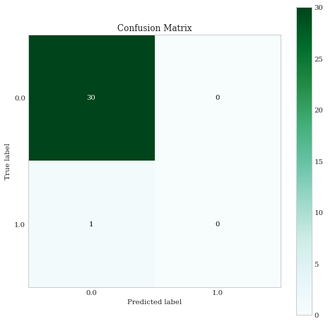

```python
skplt.metrics.plot_confusion_matrix(Y2_test, DTrfc_prediction_ctc, figsize=(8,8), cmap="BuGn")
```

Interpretation: We see that the model is exactly similar to a naive prediction!

[figure not shown]

```python
sales_features=df_honduras_bl_co_merged2.drop(['is_sales_increased'], axis=1).columns
%matplotlib inline
Importance = pd.DataFrame({'Importance':dtrfc_grid_search.best_estimator_.feature_importances_*100}, \
                          index=sales_features)
Importance.sort_values('Importance', axis=0, ascending=True).plot(kind='barh', color='lightsalmon', )
plt.gcf().set_size_inches(5, 15)
```

#### Model 5: Honduras - Let us build another model - This time we would predict a continous variable - The percentage decrease in Sales due to Covid

Dependent Variable to predict - pct_sales_decr - Continous Variable - corresponds to the question no. 'COVb2c' of the survey

- As the null values are more for pct_sales_incr, let us go with the pct_sales_decr as the Dependent Variable

```python
df_honduras_bl_co_merged.columns
```

```
Index(['idstd', 'id_x', 'd1a1x', 'd8', 'd14', 'transport_deg_obs',
       'customs_trade_reg_deg_obs', 'losses_theft', 'losses_breakage_spoilage',
       'total_sales_fy13', 'pct_sales_national_x',
       'pct_sales_indirect_exports_x', 'pct_sales_direct_exports_x',
       'total_sales', 'insuff_acc_fin_deg_obs', 'insuff_exp_gua_deg_obs',
       'high_trnspt_costs_deg_obs', 'LACd10e_deg_obs', 'is_export_fac_svc',
       'expect_vol_direct_exports', 'expect_vol_direct_exports_val',
       'is_prov_affect_cap_export', 'prov_affect_cap_export',
       'pct_sales_main_prod', 'pct_supplies_resell_domestic',
       'pct_supplies_resell_foreign', 'is_supplies_resell_imported_directly',
       'id_y', 'BPS5h', 'BPS5h1x', 'eligibilitycode', 'estbl_status',
       'is_estbl_closed_temp', 'no_weeks_estbl_closed', 'is_sales_changed',
       'pct_sales_incr', 'pct_sales_decr', 'pct_sales_national_y',
       'pct_sales_indirect_exports_y', 'pct_sales_direct_exports_y',
       'pct_dir_indir_exports_status', 'is_estbl_adjusted',
       'estbl_total_work_hrs_status', 'estbl_demand_status',
       'estbl_supply_inputs_status', 'is_biz_actvty_online',
       'is_delivery_goods_svc', 'is_remote_work_agmt',
       'is_digital_platforms_biz_admin',
       'is_digital_platforms_supply_chn_mgmt', 'is_digital_platforms_mktg',
       'is_digital_platforms_sale', 'is_digital_platforms_paymt_meth',
       'is_digital_platforms_svc_dvy', 'pct_workforce_remote',
       'pct_online_sales', 'pct_share_digi_pltms_web_sales',
       'is_estbl_invested_digi_sol', 'is_sales_increased'],
      dtype='object')
```

```python
print(df_honduras_bl_co_merged.pct_sales_incr.isna().sum())
print(df_honduras_bl_co_merged.pct_sales_decr.isna().sum())
print(df_honduras_bl_co_merged.shape)
```

```
116
85
(121, 59)
```

```python
df_honduras_bl_co_merged1 = df_honduras_bl_co_merged.dropna(axis=0, subset=['pct_sales_decr'])
print(df_honduras_bl_co_merged1.shape)
```

```
(36, 59)
```

```python
df_honduras_bl_co_merged3 = df_honduras_bl_co_merged1.drop(columns=['idstd', 'id_x', 'd1a1x', 'd8', 'd14',
       'losses_theft', 'losses_breakage_spoilage',
       'total_sales','total_sales_fy13','pct_sales_national_x',
       'pct_sales_indirect_exports_x', 'pct_sales_direct_exports_x',
       'is_sales_changed','is_export_fac_svc',
       'expect_vol_direct_exports', 'expect_vol_direct_exports_val',
       'is_prov_affect_cap_export', 'prov_affect_cap_export',
       'pct_sales_main_prod', 'pct_supplies_resell_domestic',
       'pct_supplies_resell_foreign', 'is_supplies_resell_imported_directly',
       'id_y', 'BPS5h', 'BPS5h1x', 'eligibilitycode','is_sales_increased'
       ])
df_honduras_bl_co_merged3
```

|  | transport_deg_obs | customs_trade_reg_deg_obs | insuff_acc_fin_deg_obs | insuff_exp_gua_deg_obs | high_trnspt_costs_deg_obs | LACd10e_deg_obs | estbl_status | is_estbl_closed_temp | no_weeks_estbl_closed | pct_sales_incr | ... | is_digital_platforms_biz_admin | is_digital_platforms_supply_chn_mgmt | is_digital_platforms_mktg | is_digital_platforms_sale | is_digital_platforms_paymt_meth | is_digital_platforms_svc_dvy | pct_workforce_remote | pct_online_sales | pct_share_digi_pltms_web_sales | is_estbl_invested_digi_sol |
| --- | --- | --- | --- | --- | --- | --- | --- | --- | --- | --- | --- | --- | --- | --- | --- | --- | --- | --- | --- | --- | --- |
| 2 | 0.0 | 0.0 | 0.0 | NaN | 0.0 | NaN | 0.0 | NaN | 10.0 | NaN | ... | NaN | NaN | NaN | NaN | NaN | NaN | 0.0 | 0.0 | NaN | NaN |
| 3 | 3.0 | 4.0 | NaN | NaN | NaN | NaN | 1.0 | 1.0 | 8.0 | NaN | ... | 1.0 | 0.0 | 1.0 | 1.0 | 1.0 | 0.0 | 0.0 | 0.0 | NaN | NaN |
| 6 | 4.0 | 1.0 | 4.0 | 3.0 | 3.0 | 3.0 | 1.0 | 1.0 | 4.0 | NaN | ... | NaN | NaN | NaN | NaN | NaN | NaN | 0.0 | 0.0 | NaN | NaN |
| 10 | 1.0 | 3.0 | 0.0 | 0.0 | 0.0 | 0.0 | 1.0 | 1.0 | 15.0 | NaN | ... | NaN | NaN | NaN | NaN | NaN | NaN | 0.0 | 0.0 | NaN | NaN |
| 13 | 1.0 | 3.0 | 0.0 | NaN | NaN | NaN | 0.0 | NaN | 16.0 | NaN | ... | NaN | NaN | NaN | NaN | NaN | NaN | 80.0 | 0.0 | NaN | NaN |
| 20 | 3.0 | 2.0 | 4.0 | 4.0 | 4.0 | 4.0 | 1.0 | 1.0 | 16.0 | NaN | ... | NaN | NaN | NaN | NaN | NaN | NaN | 0.0 | 0.0 | NaN | NaN |
| 23 | 4.0 | 4.0 | 0.0 | 0.0 | 1.0 | 3.0 | 1.0 | 1.0 | 1.0 | NaN | ... | 0.0 | 0.0 | 0.0 | 0.0 | 1.0 | 0.0 | 10.0 | 0.0 | NaN | NaN |
| 24 | 3.0 | 2.0 | 4.0 | 2.0 | 2.0 | 4.0 | 1.0 | 1.0 | 15.0 | NaN | ... | 1.0 | 0.0 | 1.0 | 1.0 | 1.0 | 1.0 | 40.0 | 80.0 | 0.0 | 1.0 |
| 25 | 2.0 | 2.0 | 1.0 | 3.0 | 3.0 | 3.0 | 0.0 | NaN | 12.0 | NaN | ... | 0.0 | 1.0 | 1.0 | 0.0 | 1.0 | 1.0 | 0.0 | 40.0 | 100.0 | 0.0 |
| 33 | 3.0 | 0.0 | 3.0 | 0.0 | 0.0 | 0.0 | 0.0 | NaN | 12.0 | NaN | ... | NaN | NaN | NaN | NaN | NaN | NaN | 0.0 | 0.0 | NaN | NaN |
| 35 | 0.0 | 2.0 | 0.0 | 3.0 | 2.0 | 3.0 | 0.0 | NaN | 15.0 | NaN | ... | 1.0 | 0.0 | 1.0 | 1.0 | 1.0 | 1.0 | 90.0 | 60.0 | 0.0 | 0.0 |
| 39 | 3.0 | 3.0 | 2.0 | 2.0 | 2.0 | 2.0 | 1.0 | 1.0 | 6.0 | NaN | ... | NaN | NaN | NaN | NaN | NaN | NaN | 10.0 | 0.0 | NaN | NaN |
| 45 | 0.0 | NaN | 0.0 | NaN | NaN | NaN | 1.0 | 1.0 | 6.0 | NaN | ... | 1.0 | 1.0 | 1.0 | 1.0 | 0.0 | 1.0 | 0.0 | 10.0 | 0.0 | 0.0 |
| 46 | 1.0 | 2.0 | 1.0 | 2.0 | 2.0 | 3.0 | 1.0 | 1.0 | 8.0 | NaN | ... | 0.0 | 0.0 | 0.0 | 1.0 | 1.0 | 0.0 | 5.0 | 70.0 | 0.0 | 0.0 |
| 48 | 2.0 | 2.0 | 3.0 | 2.0 | 3.0 | 3.0 | 1.0 | 1.0 | 6.0 | NaN | ... | 1.0 | 0.0 | 1.0 | 1.0 | 1.0 | 0.0 | 0.0 | 50.0 | 0.0 | 1.0 |
| 52 | 4.0 | 4.0 | 3.0 | 3.0 | 3.0 | 3.0 | 0.0 | NaN | 13.0 | NaN | ... | NaN | NaN | NaN | NaN | NaN | NaN | 2.0 | 0.0 | NaN | NaN |
| 56 | 2.0 | 1.0 | NaN | NaN | NaN | NaN | 0.0 | NaN | 12.0 | NaN | ... | 1.0 | 1.0 | 1.0 | 1.0 | 1.0 | 1.0 | 23.0 | 35.0 | 0.0 | 0.0 |
| 64 | 1.0 | 2.0 | 2.0 | 0.0 | 1.0 | 2.0 | 0.0 | NaN | 14.0 | NaN | ... | NaN | NaN | NaN | NaN | NaN | NaN | 0.0 | 0.0 | NaN | NaN |
| 65 | 1.0 | 0.0 | 3.0 | NaN | NaN | 1.0 | 1.0 | 1.0 | 16.0 | NaN | ... | 0.0 | 1.0 | 1.0 | 1.0 | 0.0 | 0.0 | 20.0 | 50.0 | 60.0 | 1.0 |
| 67 | 1.0 | 3.0 | 4.0 | 3.0 | 4.0 | 4.0 | 0.0 | NaN | 16.0 | NaN | ... | 1.0 | 1.0 | 1.0 | 1.0 | 0.0 | 1.0 | 20.0 | 100.0 | 0.0 | 1.0 |
| 69 | 3.0 | 3.0 | NaN | NaN | NaN | NaN | 0.0 | NaN | 8.0 | NaN | ... | 0.0 | 0.0 | 0.0 | 1.0 | 0.0 | 0.0 | 3.0 | 20.0 | 20.0 | 1.0 |
| 72 | 1.0 | 1.0 | 4.0 | 4.0 | 2.0 | 3.0 | 1.0 | 1.0 | 4.0 | NaN | ... | 0.0 | 0.0 | 1.0 | 1.0 | 1.0 | 1.0 | 0.0 | 40.0 | 0.0 | 0.0 |
| 73 | 0.0 | 2.0 | 0.0 | 0.0 | 2.0 | 2.0 | 1.0 | 1.0 | 3.0 | NaN | ... | 1.0 | 0.0 | 1.0 | 1.0 | 1.0 | 1.0 | 50.0 | 0.0 | NaN | NaN |
| 79 | 3.0 | 4.0 | 2.0 | 4.0 | 3.0 | 3.0 | 0.0 | NaN | 12.0 | NaN | ... | 1.0 | 0.0 | 1.0 | 1.0 | 1.0 | 0.0 | 30.0 | NaN | NaN | 0.0 |
| 81 | 3.0 | 4.0 | NaN | NaN | NaN | NaN | 1.0 | 1.0 | 8.0 | NaN | ... | 0.0 | 1.0 | 1.0 | 1.0 | 1.0 | 1.0 | 60.0 | 20.0 | 0.0 | 0.0 |
| 82 | 2.0 | 3.0 | 1.0 | 0.0 | 2.0 | 3.0 | 1.0 | 1.0 | 15.0 | NaN | ... | 0.0 | 0.0 | 0.0 | 1.0 | 1.0 | 1.0 | 20.0 | NaN | 0.0 | 1.0 |
| 84 | 1.0 | 3.0 | 0.0 | 0.0 | 1.0 | 3.0 | 0.0 | NaN | 12.0 | NaN | ... | NaN | NaN | NaN | NaN | NaN | NaN | 0.0 | 0.0 | NaN | NaN |
| 91 | 4.0 | 4.0 | 2.0 | 1.0 | 3.0 | 4.0 | 0.0 | NaN | 18.0 | NaN | ... | 1.0 | 0.0 | 1.0 | 1.0 | 1.0 | 1.0 | 0.0 | 40.0 | 0.0 | 0.0 |
| 93 | 0.0 | 0.0 | NaN | NaN | NaN | NaN | 1.0 | 1.0 | 8.0 | NaN | ... | NaN | NaN | NaN | NaN | NaN | NaN | 0.0 | 0.0 | NaN | NaN |
| 96 | 2.0 | 1.0 | 1.0 | 3.0 | NaN | 4.0 | 1.0 | 1.0 | 2.0 | NaN | ... | NaN | NaN | NaN | NaN | NaN | NaN | 0.0 | 0.0 | NaN | NaN |
| 107 | 0.0 | 0.0 | 0.0 | 1.0 | 0.0 | 0.0 | 1.0 | 1.0 | 5.0 | NaN | ... | NaN | NaN | NaN | NaN | NaN | NaN | 0.0 | 0.0 | NaN | NaN |
| 108 | 1.0 | 0.0 | 3.0 | NaN | NaN | 3.0 | 1.0 | 1.0 | 12.0 | NaN | ... | NaN | NaN | NaN | NaN | NaN | NaN | 0.0 | 0.0 | NaN | NaN |
| 110 | 0.0 | 4.0 | NaN | NaN | NaN | NaN | 1.0 | 1.0 | 15.0 | NaN | ... | 0.0 | 0.0 | 1.0 | 1.0 | 0.0 | 0.0 | 0.0 | 100.0 | 100.0 | 1.0 |
| 113 | NaN | NaN | NaN | NaN | NaN | NaN | 0.0 | NaN | 18.0 | NaN | ... | NaN | NaN | NaN | NaN | NaN | NaN | 100.0 | 0.0 | NaN | NaN |
| 114 | 0.0 | NaN | 2.0 | 2.0 | 3.0 | 3.0 | 0.0 | NaN | 14.0 | NaN | ... | NaN | NaN | NaN | NaN | NaN | NaN | 0.0 | 0.0 | NaN | NaN |
| 116 | 1.0 | 3.0 | 0.0 | NaN | NaN | 1.0 | 1.0 | 1.0 | 8.0 | NaN | ... | 0.0 | 0.0 | 1.0 | 1.0 | 1.0 | 1.0 | 0.0 | NaN | NaN | 1.0 |

36 rows × 32 columns

```python
# First, define the X (predictor/independent) and the Y (predicted/dependent) variables:
# SciKit doesn't work with Pandas dataframes, so we just need the matrix of values.

X = df_honduras_bl_co_merged3[['transport_deg_obs', 'customs_trade_reg_deg_obs',
       'insuff_acc_fin_deg_obs', 'insuff_exp_gua_deg_obs',
       'high_trnspt_costs_deg_obs', 'LACd10e_deg_obs', 'estbl_status',
       'is_estbl_closed_temp', 'no_weeks_estbl_closed', 'pct_sales_incr',
       'pct_sales_national_y',
       'pct_sales_indirect_exports_y', 'pct_sales_direct_exports_y',
       'pct_dir_indir_exports_status', 'is_estbl_adjusted',
       'estbl_total_work_hrs_status', 'estbl_demand_status',
       'estbl_supply_inputs_status', 'is_biz_actvty_online',
       'is_delivery_goods_svc', 'is_remote_work_agmt',
       'is_digital_platforms_biz_admin',
       'is_digital_platforms_supply_chn_mgmt', 'is_digital_platforms_mktg',
       'is_digital_platforms_sale', 'is_digital_platforms_paymt_meth',
       'is_digital_platforms_svc_dvy', 'pct_workforce_remote',
       'pct_online_sales', 'pct_share_digi_pltms_web_sales',
       'is_estbl_invested_digi_sol']].values
Y = df_honduras_bl_co_merged3.pct_sales_decr
```

```python
# Second, split the data into training and test portions:
# I am using 25% of data for testing and 75% for training.

X_train, X_test, Y_train, Y_test = train_test_split(X, Y, test_size=0.25, random_state=7)
print(X_train.shape, Y_train.shape)
print(X_test.shape, Y_test.shape)
```

```
(27, 31) (27,)
(9, 31) (9,)
```

```python
DTsalesreg=DecisionTreeRegressor(random_state=23)
```

```python
# set the gridsearch parameters for the decision tree regression
dtr_param_grid={'max_depth':[3,5,7,10], 'max_leaf_nodes':np.arange(2,10)}
```

```python
# define the gridsearch for the decision tree regression:

dtr_grid_search = GridSearchCV(DTsalesreg, dtr_param_grid, cv=5, scoring='neg_mean_squared_error')
```

```python
# Fit the model on training data
# Since we are using the training portion of the data, we are now "training" our model.
dtr_grid_search.fit(X_train, Y_train)
```

[output not shown]

[output cut: 585 more lines]

[output not shown]

[output not shown]

```python
df_honduras_bl_co_merged3.fillna(0,inplace=True)
```

Each row in the dataFrame corresponds to a company and it is tricky to fill the missing data. We cannot use median or mean values to fill the missing data for any column as this would apply to all rows wherever null value is present such as *dfSoy.fillna({'precip' : dfSoy['precip'].mean(), 'temp':dfSoy['temp'].median()}, inplace=True)*  
because the survey is not for a single entity but multiple entities/companies and we cannot generalize the sales figure or the obstacles faced, percentage sales direct, indirect exports etc. if the value is Dont know because all these attributes are company-specific, therefore cant be generalized per se.

### These are the input/output variables

```python
# First, define the X (predictor/independent) and the Y (predicted/dependent) variables:
# SciKit doesn't work with Pandas dataframes, so we just need the matrix of values.

X = df_honduras_bl_co_merged3[['transport_deg_obs', 'customs_trade_reg_deg_obs',
       'insuff_acc_fin_deg_obs', 'insuff_exp_gua_deg_obs',
       'high_trnspt_costs_deg_obs', 'LACd10e_deg_obs', 'estbl_status',
       'is_estbl_closed_temp', 'no_weeks_estbl_closed', 'pct_sales_incr',
       'pct_sales_national_y',
       'pct_sales_indirect_exports_y', 'pct_sales_direct_exports_y',
       'pct_dir_indir_exports_status', 'is_estbl_adjusted',
       'estbl_total_work_hrs_status', 'estbl_demand_status',
       'estbl_supply_inputs_status', 'is_biz_actvty_online',
       'is_delivery_goods_svc', 'is_remote_work_agmt',
       'is_digital_platforms_biz_admin',
       'is_digital_platforms_supply_chn_mgmt', 'is_digital_platforms_mktg',
       'is_digital_platforms_sale', 'is_digital_platforms_paymt_meth',
       'is_digital_platforms_svc_dvy', 'pct_workforce_remote',
       'pct_online_sales', 'pct_share_digi_pltms_web_sales',
       'is_estbl_invested_digi_sol']].values
Y = df_honduras_bl_co_merged3.pct_sales_decr
```

```python
# Second, split the data into training and test portions:
# I am using 25% of data for testing and 75% for training.

X_train, X_test, Y_train, Y_test = train_test_split(X, Y, test_size=0.25, random_state=7)
print(X_train.shape, Y_train.shape)
print(X_test.shape, Y_test.shape)
```

```
(27, 31) (27,)
(9, 31) (9,)
```

```python
DTsalesreg=DecisionTreeRegressor(random_state=23)
```

```python
# set the gridsearch parameters for the decision tree regression
dtr_param_grid={'max_depth':[3,5,7,10], 'max_leaf_nodes':np.arange(2,10)}
```

```python
# define the gridsearch for the decision tree regression:

dtr_grid_search = GridSearchCV(DTsalesreg, dtr_param_grid, cv=5, scoring='neg_mean_squared_error')
```

```python
# Fit the model on training data
# Since we are using the training portion of the data, we are now "training" our model.
dtr_grid_search.fit(X_train, Y_train)
```

```
GridSearchCV(cv=5, error_score=nan,
             estimator=DecisionTreeRegressor(ccp_alpha=0.0, criterion='mse',
                                             max_depth=None, max_features=None,
                                             max_leaf_nodes=None,
                                             min_impurity_decrease=0.0,
                                             min_impurity_split=None,
                                             min_samples_leaf=1,
                                             min_samples_split=2,
                                             min_weight_fraction_leaf=0.0,
                                             presort='deprecated',
                                             random_state=23, splitter='best'),
             iid='deprecated', n_jobs=None,
             param_grid={'max_depth': [3, 5, 7, 10],
                         'max_leaf_nodes': array([2, 3, 4, 5, 6, 7, 8, 9])},
             pre_dispatch='2*n_jobs', refit=True, return_train_score=False,
             scoring='neg_mean_squared_error', verbose=0)
```

```python
dtr_grid_search.cv_results_['mean_test_score']
```

```
array([ -536.61409196,  -535.78684406,  -545.9071734 ,  -961.74143266,
        -987.35677083, -1017.04699074, -1049.14074074, -1049.14074074,
        -536.61409196,  -535.78684406,  -545.9071734 ,  -961.74143266,
        -987.35677083, -1001.14625   , -1001.14625   , -1057.41143519,
        -536.61409196,  -535.78684406,  -545.9071734 ,  -961.74143266,
        -987.35677083, -1001.14625   , -1001.14625   , -1057.41143519,
        -536.61409196,  -535.78684406,  -545.9071734 ,  -961.74143266,
        -987.35677083, -1001.14625   , -1001.14625   , -1057.41143519])
```

```python
dtr_grid_search.best_params_
```

```
{'max_depth': 3, 'max_leaf_nodes': 3}
```

```python
dtr_grid_search.best_estimator_
```

```
DecisionTreeRegressor(ccp_alpha=0.0, criterion='mse', max_depth=3,
                      max_features=None, max_leaf_nodes=3,
                      min_impurity_decrease=0.0, min_impurity_split=None,
                      min_samples_leaf=1, min_samples_split=2,
                      min_weight_fraction_leaf=0.0, presort='deprecated',
                      random_state=23, splitter='best')
```

We can visualize the Decision Tree from the best*estimator* as following:

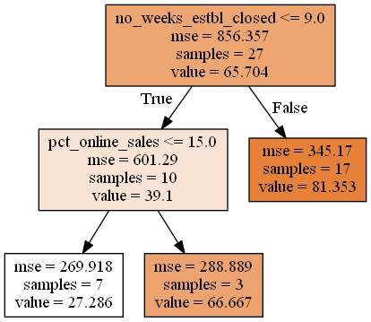

```python
DTRgraph = print_tree(dtr_grid_search.best_estimator_, features=['transport_deg_obs', 'customs_trade_reg_deg_obs',
       'insuff_acc_fin_deg_obs', 'insuff_exp_gua_deg_obs',
       'high_trnspt_costs_deg_obs', 'LACd10e_deg_obs', 'estbl_status',
       'is_estbl_closed_temp', 'no_weeks_estbl_closed', 'pct_sales_incr',
       'pct_sales_national_y',
       'pct_sales_indirect_exports_y', 'pct_sales_direct_exports_y',
       'pct_dir_indir_exports_status', 'is_estbl_adjusted',
       'estbl_total_work_hrs_status', 'estbl_demand_status',
       'estbl_supply_inputs_status', 'is_biz_actvty_online',
       'is_delivery_goods_svc', 'is_remote_work_agmt',
       'is_digital_platforms_biz_admin',
       'is_digital_platforms_supply_chn_mgmt', 'is_digital_platforms_mktg',
       'is_digital_platforms_sale', 'is_digital_platforms_paymt_meth',
       'is_digital_platforms_svc_dvy', 'pct_workforce_remote',
       'pct_online_sales', 'pct_share_digi_pltms_web_sales',
       'is_estbl_invested_digi_sol'])
Image(DTRgraph.create_png())
```

```python
# Get the predicted values and evaluate the model:

DT_predictions_tr=dtr_grid_search.best_estimator_.predict(X_test) # predictions for test set
```

```python
# How good is this prediction?

np.sqrt(np.square(DT_predictions_tr-Y_test).mean()) #RMSE calculation
```

```
20.565137526878853
```

Interpretation: Our model is deviant from the actual values by about 20.56%, on average when using the test data. Moreover, It depends on how good the accuracy has to be depending on the context.

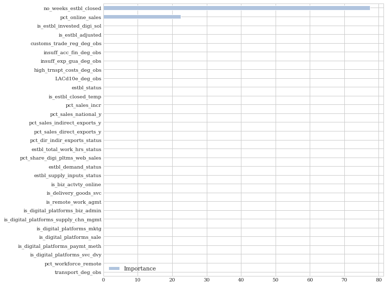

```python
#Getting the importance of features from the best model:
%matplotlib inline
Importance = pd.DataFrame({'Importance':dtr_grid_search.best_estimator_.feature_importances_*100}, \
                          index=['transport_deg_obs', 'customs_trade_reg_deg_obs',
       'insuff_acc_fin_deg_obs', 'insuff_exp_gua_deg_obs',
       'high_trnspt_costs_deg_obs', 'LACd10e_deg_obs', 'estbl_status',
       'is_estbl_closed_temp', 'no_weeks_estbl_closed', 'pct_sales_incr',
       'pct_sales_national_y',
       'pct_sales_indirect_exports_y', 'pct_sales_direct_exports_y',
       'pct_dir_indir_exports_status', 'is_estbl_adjusted',
       'estbl_total_work_hrs_status', 'estbl_demand_status',
       'estbl_supply_inputs_status', 'is_biz_actvty_online',
       'is_delivery_goods_svc', 'is_remote_work_agmt',
       'is_digital_platforms_biz_admin',
       'is_digital_platforms_supply_chn_mgmt', 'is_digital_platforms_mktg',
       'is_digital_platforms_sale', 'is_digital_platforms_paymt_meth',
       'is_digital_platforms_svc_dvy', 'pct_workforce_remote',
       'pct_online_sales', 'pct_share_digi_pltms_web_sales',
       'is_estbl_invested_digi_sol'])
Importance.sort_values('Importance', axis=0, ascending=True).plot(kind='barh', color='lightsteelblue', )
plt.gcf().set_size_inches(10, 10)
```

```python
print(df_honduras_baseline.query("a0 == 'Retail services'").shape)
print(df_honduras_baseline.query("a0 == 'Manufacturing'").shape)
print(df_honduras_baseline.query("a0 == 'Other services'").shape)
```

[output not shown]

```python
print(len(df_elsalvador_bl_co_merged2.columns))
print(len(df_elsalvador_bl_co_merged3.columns))
```

```
33
32
```

```python
df_elsalvador_bl_co_merged3.columns
```

```
Index(['transport_deg_obs', 'customs_trade_reg_deg_obs',
       'insuff_acc_fin_deg_obs', 'insuff_exp_gua_deg_obs',
       'high_trnspt_costs_deg_obs', 'LACd10e_deg_obs', 'estbl_status',
       'is_estbl_closed_temp', 'no_weeks_estbl_closed', 'pct_sales_incr',
       'pct_sales_decr', 'pct_sales_national_y',
       'pct_sales_indirect_exports_y', 'pct_sales_direct_exports_y',
       'pct_dir_indir_exports_status', 'is_estbl_adjusted',
       'estbl_total_work_hrs_status', 'estbl_demand_status',
       'estbl_supply_inputs_status', 'is_biz_actvty_online',
       'is_delivery_goods_svc', 'is_remote_work_agmt',
       'is_digital_platforms_biz_admin',
       'is_digital_platforms_supply_chn_mgmt', 'is_digital_platforms_mktg',
       'is_digital_platforms_sale', 'is_digital_platforms_paymt_meth',
       'is_digital_platforms_svc_dvy', 'pct_workforce_remote',
       'pct_online_sales', 'pct_share_digi_pltms_web_sales',
       'is_estbl_invested_digi_sol'],
      dtype='object')
```